# 25 days of chRistmas: an R advent calendaR!

**BEFORE WE BEGIN** This is an [R Markdown](http://rmarkdown.rstudio.com) Notebook. When you execute code within the notebook, the results appear beneath the code.

## Okay… now back to our calendaR!

**25 days of chRistmas: an R advent calendaR**

### DAY 1

On the first day of Christmas my true love (or some random person from the internet) gave to me…

…the weirdest advent calendar ever: a 25-day R tutorial!

While this is arguably less delicious than chocolate (depends who you ask), it might prove to be more useful (again, depends who you ask).

I’ve put together a very different type of advent calendar this year, one that will teach you some of the basics in R. Every day you will learn one new little thing. This is designed for people who have zero experience using R, and each day is meant to take only a few minutes. By Christmas, you should have a nice R script summarizing some of the basic concepts in R!

So for day one all you have to do is make sure you have R downloaded. One of the best things about R is that it is free and open source!

Also, I recommend you download R Studio (also free) and use that instead of R (but you might need to have R as well for R Studio to work).

https://mirror.its.dal.ca/cran/

https://rstudio.com/products/rstudio/download/

That is all for today. If you want to make your R studio more fun, you can go to Preferences > Appearance (Mac), then choose a fun colour combo for your R Studio! Pro tip: for some reason people think you’re some sort of coding wiz when you use a dark background with light text, I have no idea why.

### DAY 2

On the second day of Christmas…

…you will familiarize yourself with the layout of R Studio.

You should see four windows in front of you.

Top left is the “source” window. This is where you see your script and where you type your code. You will typically want to save your script (i.e. everything in this window) fairly regularly.

**Scripts will be saved as an R script file. If you open a saved script file it will show in the source window. You can have multiple scripts open at the same time as tabs. This is also true for R Markdown (.rmd) files, which we are currently working in!

Bottom left is the “console”. When we type run code in our script (displayed in our source window), you should see some sort of output in the console. Some examples: If you run a code and there’s something wrong with it, this is where you will see the error message. If you run a statistical test, this is where the results will be displayed.

Top right is the “environment: window. This shows a list of all the data, values, and functions you currently have available in R studio. If you create a new vector, it will be added to this list.

Bottom right is where your packages, plots, and help will be displayed. If you create a plot, this is where it will pop up. A list of all packages currently downloaded and loaded is under the ‘packages’ tab. The “help” tab is a handy resource - we will talk more about this later on.

### DAY 3

On the third day of Christmas…

…you get to learn how to set your working directory (and also check where your working directory is!).

Start by making sure the “advent_calendaR” folder is on your desktop (or create one with that exact file name, advent_calendaR - note: R is case sensitive so make sure you get that capital R in there!). You can change your working directory in the future when you’ve set up a proper folder for your R data and scripts. For the purpose of this tutorial, we’ll make the advent_calendar folder your working directory.

Also make sure that the two .csv files are in your advent_calendaR folder. This will be important in the days ahead…

```r
getwd()
```

```
[1] "/Users/kiirsti/Desktop/advent_calendaR"
```

To run your code, click anywhere in the line of code and press command + enter at the same time. You should see the output from your code in the console! Did it work?

In R Markdowm (or R Notebook files), remember that you can also run the code by clicking the little green arrow to the right. This will run the entire “chunk”.

setwd() and getwd() are examples of ‘functions’. Functions perform specific tasks and are usually identified as a word or combination of words followed by (). We usually fill in () with what we want the function to act on - though as you can see with getwd() we don’t always need to fill in ()

### DAY 4

On the fourth day of Christmas…

…you’re going to play with numbers!

Here’s some basic code you can run. Just like in Excel or on a calculator, R can do simple calculations for you so that you don’t have to think too hard!

To run each line at a time, click anywhere in the line of code and run each line. To run them all at once, highlight the entire code and run it. R shortcut: to run code press Ctrl + enter (PC) or Command + enter (Mac). ** Remember ** in R Markdown you can also run all the code at once by pressing the green arrow. Notice that in R Markdown, the output will appear directly below the chunk AND in the console.

```r
2+5
```

```
[1] 7
```

```r
2^5
```

```
[1] 32
```

```r
67^8
```

```
[1] 4.060677e+14
```

```r
log(25)
```

```
[1] 3.218876
```

```r
sqrt(25)
```

```
[1] 5
```

```r
abs(-25)
```

```
[1] 25
```

P.S. log(), sqrt(), abs() are examples of functions (more about this soon…)

### DAY 5

On the fifth day of Christmas…

…you will learn of a very helpful little tool…. the ?

When you’re not sure what a function does or you can’t remember, simple type ? in front of it, then run that line of code.

Try it:

```r
?sqrt
```

*Note: ?sqrt() or ?sqrt will give you the same output

Some other helpful tips:

- Don’t forget that R is case sensitive! For example, Sqrt() will not work
- When you get error messages, it’s often because of a minor typo or perhaps a missed or extra bracket, comma, etc. Double check your code and try again.

### DAY 6

On the sixth day of Christmas…

…you going to learn about vectors!

Instead of a single number or character, vectors allow us to group many together.

For example, run this line of code:

```r
numbers
```

```
[1] 1 2 3 4 5
```

Now highlight just the word ‘numbers’ or retype it below and run it. Your numbers should come up in the output. Just like that! You just created a vector. This is called a numeric vector. Note that the numbers do not need to be in “ “.

The other type of vector is called a character vector. Here’s a fun one:

```r
hi
```

```
[1] "Happy holidays, I hope you have a wonderful day!"
```

I’ve typed “hi” below, so you can run that (or highlight the word hi in your console and run). Note that the words DO need to be in ““. Also note: if your vector includes words and numbers, R will consider everything as characters.

Vectors make our lives easier when we don’t want to type out long lists of code (especially if the vector is an entire dataset!).

As an example of what we can do with a vector, let’s do something with your first vector:

```r
sum(numbers)
```

```
[1] 15
```

Vectors are super useful, you will use them a lot.

***R fun fact: the c in c() stands for “concatenate” or ‘to link together’. You can save that one for parties with other R nerds. You’re welcome.

### DAY 7

On the seventh day of Christmas…

…you will learn about operators.

You’re already seen <- (referred to as the ‘assignment operator’).

Here are some useful logical operators you might need to use. If you forget them, search “logical operators in R” online. Or type this code into R: ?base::Logic

Check it out:

```r
?base::Logic
```

< less than <= less than or equal to > greater than >= greater than or equal to == exactly equal to != not equal to

Try them out with these codes:

```r
x <-2
y <-10
x<y
```

```
[1] TRUE
```

```r
x>y
```

```
[1] FALSE
```

```r
y>=100
```

```
[1] FALSE
```

### DAY 8

On the eighth day of Christmas…

…you’re going to load data into R!

For this we use the function, read.csv(). If you have your working directory set, and if your .csv file is in that working directory, then all you need to do is type in the file name. When loading your data, create a new vector and give is a meaningful but short name, such as tree.dat for Christmas tree data.

| name | km_per_carrot | bag_space | deerpower | width | weight | colour | reins | bells |
| --- | --- | --- | --- | --- | --- | --- | --- | --- |
| Jingle 3000 | 21.0 | 160.0 | 110 | 3.90 | 2.620 | 1 | 4 | 6 |
| Jingle 4000 | 21.0 | 160.0 | 110 | 3.90 | 2.875 | 1 | 4 | 6 |
| North Pole | 22.8 | 108.0 | 93 | 3.85 | 2.320 | 1 | 4 | 4 |
| Winter Express | 21.4 | 258.0 | 110 | 3.08 | 3.215 | 0 | 3 | 6 |
| Christmas Cruiser | 18.7 | 360.0 | 175 | 3.15 | 3.440 | 0 | 3 | 8 |
| The Blitzen | 18.1 | 225.0 | 105 | 2.76 | 3.460 | 0 | 3 | 6 |
| Stealth Sleigh | 14.3 | 360.0 | 245 | 3.21 | 3.570 | 0 | 3 | 8 |
| Flying Polesman | 24.4 | 146.7 | 62 | 3.69 | 3.190 | 0 | 4 | 4 |
| The Vintage | 22.8 | 140.8 | 95 | 3.92 | 3.150 | 0 | 4 | 4 |
| Frosty Flier | 19.2 | 167.6 | 123 | 3.92 | 3.440 | 0 | 4 | 6 |

[output cut: 23 more lines]

Now retype sl.dat (as I have done here) or highlight it in the code above and run it. You data should pop up directly below the chunk that you just ran. You might also notice that sl.dat is now in your Environment —–> check it out. Try clicking on sl.dat and see what happens. You can’t edit this file like you would with Excel by clicking and typing, this is just a preview. But it is helpful if you want to see what the data look like.

You can also use str(sl.dat) to get a more concise summary of your data. Santa’s is looking to buy a new sleigh. His elves put together this list of the top models on the market.

```r
str(sl.dat)
```

```
'data.frame':   33 obs. of  9 variables:
 $ name         : chr  "Jingle 3000" "Jingle 4000" "North Pole" "Winter Express" ...
 $ km_per_carrot: num  21 21 22.8 21.4 18.7 18.1 14.3 24.4 22.8 19.2 ...
 $ bag_space    : num  160 160 108 258 360 ...
 $ deerpower    : int  110 110 93 110 175 105 245 62 95 123 ...
 $ width        : num  3.9 3.9 3.85 3.08 3.15 2.76 3.21 3.69 3.92 3.92 ...
 $ weight       : num  2.62 2.88 2.32 3.21 3.44 ...
 $ colour       : int  1 1 1 0 0 0 0 0 0 0 ...
 $ reins        : int  4 4 4 3 3 3 3 4 4 4 ...
 $ bells        : int  6 6 4 6 8 6 8 4 4 6 ...
```

name = name of the sleigh model (there are 33 rows of sleigh models).

km_per_carrot = how many kilometres the sleigh can go based on reindeer energy (measured in carrots)

bag_space = the amount of space in the back of the sleigh for Santa’s toy bag. Units aren’t important.

deer power = similar to horsepower in cars

width = width of the sleigh in meters

weight = weight of the sleigh in grams (sleighs are magical and thus weigh VERY little!)

colour = 0 is the code for green and 1 is the code for red. Santa wouldn’t even consider any other colours.

reins = the number of reins the sleigh is equipped with

bells = number of magical bells on the sleigh.

Note that the different variables are represented as different data types: name is a character, km_per_carrot is numeric (numbers that contain a decimal), bells is an integer (whole numbers). Logical is another data type, which is for data that have a value or TRUE or FALSE, but we don’t have any logical data in this dataset.

**Note** If your file was not in your working directory, you would need to specify the location. You would use similar code to when you set your working directory.

E.g. if your file was on the Desktop, you might use:

read.csv(“~Desktop/“sleigh.data.csv”)

Note: these data are based on a preloaded R dataset called mtcars. I edited it to fit the theme, and I removed a few columns to make it slightly simpler.

### DAY 9

On the ninth day of Christmas…

…you’re going to have a look at the data you loaded yesterday!

Make sure your data are loaded. Let’s have a look at just the column names so we are reminded of the position of each column.

```r
colnames(sl.dat)
```

```
[1] "name"          "km_per_carrot" "bag_space"     "deerpower"     "width"         "weight"        "colour"
[8] "reins"         "bells"
```

You can do the same for rows, which isn’t as meaningful here, but could be with other datasets.

```r
rownames(sl.dat)
```

```
 [1] "1"  "2"  "3"  "4"  "5"  "6"  "7"  "8"  "9"  "10" "11" "12" "13" "14" "15" "16" "17" "18" "19" "20" "21" "22" "23" "24" "25"
[26] "26" "27" "28" "29" "30" "31" "32" "33"
```

We want to isolate the column that looks at how much deerpower the sleighs have. There are several ways we can do this, one way is to identify the column position.

```r
sl.dat[,4]
```

```
 [1] 110 110  93 110 175 105 245  62  95 123 123 180 180 180 205 215 230  66  52  65  97 150 150 245 175  66  91 113 264 175 335
[32] 109  NA
```

Note we use [ ] instead of ( ).

Now we want to look at a single row. Let’s look at the Christmas Cruiser. This is the 5th line down in our dataset.

|  | name | km_per_carrot | bag_space | deerpower | width | weight | colour | reins | bells |
| --- | --- | --- | --- | --- | --- | --- | --- | --- | --- |
| 5 | Christmas Cruiser | 18.7 | 360 | 175 | 3.15 | 3.44 | 0 | 3 | 8 |

Let’s say we just want to call up how much bag space the Christmas Cruiser has and ignore the other stuff

```r
sl.dat[5,3]
```

```
[1] 360
```

### DAY 10

On the tenth day of Christmas…

..you’re going to learn how to install packages!

What are packages you ask? (pretend you asked)

Let me tell you! “R packages are a collection of R functions, complied code and sample data. They are stored under a directory called”library” in the R environment.” (https://www.tutorialspoint.com/r/r_packages.htm). If you click on the “packages” tab in R studio you can see all the packages you currently have downloaded in R. Loaded packages will have checkmarks beside them.

We’re going to install “dplyr” which is a SUPER useful app for data-wrangling.

```r
install.packages("dplyr")
```

Pause and wait for it to install…then load the new package!

```r
library(dplyr)
```

Note, the package name must be in “” to install, but not to load.

Like with functions, you can use ?dplyr to learn more about the package.

```r
?dplyr
```

**TIP** If you close R and reopen it another time, you will need to reload the package (but not reinstall it). This is also true for any vectors or data you previously ran. Many things will need to be rerun….for this reason I often leave R Studio open.

I usually keep a list of packages at the top of a R script I’m working on and run them when I reopen a file.

Example:

library(dplyr) library(vegan) library(lme4) library(ggplot2)

### DAY 11

On the eleventh day of Christmas…

…you’re going to learn how to check which version of R you’re using and how to update packages.

R and its many packages are often being updated and improved by the amazing R community and development team. This means that sometimes you need to update R or packages.

First, how to find out which version you’re currently using:

It’s easy! Run this simple code:

```r
R.version
```

```
               _
platform       aarch64-apple-darwin20
arch           aarch64
os             darwin20
system         aarch64, darwin20
status
major          4
minor          3.1
year           2023
month          06
day            16
svn rev        84548
language       R
version.string R version 4.3.1 (2023-06-16)
nickname       Beagle Scouts
```

*Note: this will give you the version of R you’re using, not the version of R Studio. Both may need to be periodically updated.

What about updating packages?

First, you can find out if any of your packages have available updates:

```r
old.packages()
```

[output not shown]

[output cut: 51 more lines]

[output not shown]

Then you can update them with this code:

```r
update.packages()
```

If you want to update them all without having to give permission:

```r
update.packages(ask=FALSE)
```

Oh geez, I just test-ran this code and it took a while to update all my packages!! So here’s a fun little fact. If you are running code that takes a while (think big datasets, fancy models…it can take minutes, hours, days even!), you can use the package beepr to alert you when your code has finished running. This is handy if you want to check emails, play a few rounds of Solitaire, or catch up on some online Christmas shopping…

Try it:

```r
install.packages("beepr")
```

Beep(2) is my favourite (and also my text tone on my phone). Here are some of the other sounds, just change the number in the brackets. 1. “ping” 2. “coin” 3. “fanfare” 4. “complete” 5. “treasure” 6. “ready” 7. “shotgun” 8. “mario” 9. “wilhelm” 10. “facebook”

To use this, you would run your line of code for your fancy model (or whatever) and then immediately run your beep() function. R will run the beep() as soon as it finishes with your time-consuming code.

### DAY 12

On the twelfth day of Christmas…

…you get to subset data by rows!

We’re going to subset the data for the different sleigh types and create new vectors.

Easy peasy! We first tell R which data to use, then identify the condition to subset by.

Let’s organize green and red sleighs into separate vectors.

|  | name | km_per_carrot | bag_space | deerpower | width | weight | colour | reins | bells |
| --- | --- | --- | --- | --- | --- | --- | --- | --- | --- |
| 1 | Jingle 3000 | 21.0 | 160.0 | 110 | 3.90 | 2.620 | 1 | 4 | 6 |
| 2 | Jingle 4000 | 21.0 | 160.0 | 110 | 3.90 | 2.875 | 1 | 4 | 6 |
| 3 | North Pole | 22.8 | 108.0 | 93 | 3.85 | 2.320 | 1 | 4 | 4 |
| 18 | Mean Green Machine | 32.4 | 78.7 | 66 | 4.08 | 2.200 | 1 | 4 | 4 |
| 19 | The Kringle | 30.4 | 75.7 | 52 | 4.93 | 1.615 | 1 | 4 | 4 |
| 20 | Wonderland Express | 33.9 | 71.1 | 65 | 4.22 | 1.835 | 1 | 4 | 4 |
| 26 | The Red Nose | 27.3 | 79.0 | 66 | 4.08 | 1.935 | 1 | 4 | 4 |
| 27 | Polar Express | 26.0 | 120.3 | 91 | 4.43 | 2.140 | 1 | 5 | 4 |
| 28 | Zephyr | 30.4 | 95.1 | 113 | 3.77 | 1.513 | 1 | 5 | 4 |
| 29 | Winter Whirlwind | 15.8 | 351.0 | 264 | 4.22 | 3.170 | 1 | 5 | 8 |

[output cut: 4 more lines]

You can highlight and run red and green here, or type them out and run them. Check to see that it worked.

**Note: you need to use double == here instead of =

You can go further and subset rows from your subsets.

|  | name | km_per_carrot | bag_space | deerpower | width | weight | colour | reins | bells |
| --- | --- | --- | --- | --- | --- | --- | --- | --- | --- |
| 4 | Winter Express | 21.4 | 258.0 | 110 | 3.08 | 3.215 | 0 | 3 | 6 |
| 5 | Christmas Cruiser | 18.7 | 360.0 | 175 | 3.15 | 3.440 | 0 | 3 | 8 |
| 6 | The Blitzen | 18.1 | 225.0 | 105 | 2.76 | 3.460 | 0 | 3 | 6 |
| 7 | Stealth Sleigh | 14.3 | 360.0 | 245 | 3.21 | 3.570 | 0 | 3 | 8 |
| 8 | Flying Polesman | 24.4 | 146.7 | 62 | 3.69 | 3.190 | 0 | 4 | 4 |
| 9 | The Vintage | 22.8 | 140.8 | 95 | 3.92 | 3.150 | 0 | 4 | 4 |
| 10 | Frosty Flier | 19.2 | 167.6 | 123 | 3.92 | 3.440 | 0 | 4 | 6 |
| 11 | Noel Navigator | 17.8 | 167.6 | 123 | 3.92 | 3.440 | 0 | 4 | 6 |
| 12 | Christmas Continental | 16.4 | 275.8 | 180 | 3.07 | 4.070 | 0 | 3 | 8 |
| 13 | Snow Much Fun | 17.3 | 275.8 | 180 | 3.07 | 3.730 | 0 | 3 | 8 |

[output cut: 9 more lines]

**FYI: the function filter() from package dplyr, which we installed the other day, does essentially the same thing as the function subset().

### DAY 13

On the thirteenth day of Christmas (unlike the song, our days keep going!)…

…you’re going to subset data by columns.

For this we’re going to use the package you installed recently, dplyr.

There are many ways to subset columns, but we’re going to use select().

Let’s create a new vector called sl_var that subsets out our sleigh variables, and doesn’t include the names of the sleighs.

| km_per_carrot | bag_space | deerpower | width | weight | colour | reins | bells |
| --- | --- | --- | --- | --- | --- | --- | --- |
| 21.0 | 160.0 | 110 | 3.90 | 2.620 | 1 | 4 | 6 |
| 21.0 | 160.0 | 110 | 3.90 | 2.875 | 1 | 4 | 6 |
| 22.8 | 108.0 | 93 | 3.85 | 2.320 | 1 | 4 | 4 |
| 21.4 | 258.0 | 110 | 3.08 | 3.215 | 0 | 3 | 6 |
| 18.7 | 360.0 | 175 | 3.15 | 3.440 | 0 | 3 | 8 |
| 18.1 | 225.0 | 105 | 2.76 | 3.460 | 0 | 3 | 6 |
| 14.3 | 360.0 | 245 | 3.21 | 3.570 | 0 | 3 | 8 |
| 24.4 | 146.7 | 62 | 3.69 | 3.190 | 0 | 4 | 4 |
| 22.8 | 140.8 | 95 | 3.92 | 3.150 | 0 | 4 | 4 |
| 19.2 | 167.6 | 123 | 3.92 | 3.440 | 0 | 4 | 6 |

[output cut: 23 more lines]

Using select() everything in between the two points identified, so here this includes km_per_carrot, bag_space, deerpower, width, weight, colour, reins, and bells.

If we wanted all of these variables but wanted to exclude deerpower, we can use…

| km_per_carrot | bag_space | width | weight | colour | reins | bells |
| --- | --- | --- | --- | --- | --- | --- |
| 21.0 | 160.0 | 3.90 | 2.620 | 1 | 4 | 6 |
| 21.0 | 160.0 | 3.90 | 2.875 | 1 | 4 | 6 |
| 22.8 | 108.0 | 3.85 | 2.320 | 1 | 4 | 4 |
| 21.4 | 258.0 | 3.08 | 3.215 | 0 | 3 | 6 |
| 18.7 | 360.0 | 3.15 | 3.440 | 0 | 3 | 8 |
| 18.1 | 225.0 | 2.76 | 3.460 | 0 | 3 | 6 |
| 14.3 | 360.0 | 3.21 | 3.570 | 0 | 3 | 8 |
| 24.4 | 146.7 | 3.69 | 3.190 | 0 | 4 | 4 |
| 22.8 | 140.8 | 3.92 | 3.150 | 0 | 4 | 4 |
| 19.2 | 167.6 | 3.92 | 3.440 | 0 | 4 | 6 |

[output cut: 23 more lines]

### DAY 14

On the fourteenth day of Christmas…

…you’re going to learn about another useful dplyr function: mutate()!

Mutate() is used to add a new variable or column to your existing data. Let’s pretend we wanted to know the number of needles dropped per tree by it’s height (I don’t know why we would want to know this…but for the sake of the example we will pretend it’s important).

Let’s load a new dataset called xmas.trees.csv

```r
tree.dat <-read.csv(“xmas.trees.csv")
```

[output not shown]

This dataset compares different types of christmas trees. Data were collected on three different types of trees: pines, firs, and spruces. Data collected included the height of the tree, the quality of the fragrance on a scale of 1 to 10, the number of needles dropped in one week, and the amount of ‘Christmas magic’ the tree had on a continuous scale with imaginary units.

| type | height | fragrance | needle.drop | xmas.magic | needles.by.height |
| --- | --- | --- | --- | --- | --- |
| pine | 5.5 | 5.0 | 25 | 4.5 | 4.545455 |
| pine | 4.2 | 4.0 | 40 | 4.2 | 9.523810 |
| pine | 6.1 | 6.0 | 35 | 5.8 | 5.737705 |
| pine | 4.3 | 5.0 | 40 | 5.0 | 9.302326 |
| pine | 5.0 | 3.0 | 30 | 2.7 | 6.000000 |
| pine | 5.6 | 4.0 | 20 | 6.9 | 3.571429 |
| pine | 7.1 | 4.5 | 25 | 5.1 | 3.521127 |
| pine | 6.0 | 5.0 | 25 | 4.6 | 4.166667 |
| pine | 6.6 | 5.0 | 30 | 6.1 | 4.545455 |
| pine | 7.2 | 5.5 | 35 | 6.0 | 4.861111 |

[output cut: 20 more lines]

First we identify the dataset we want to add the new variable or column to, in this case tree.dat. Then we use this handy little trick %>% that’s called ‘piping’. It means “and then”, as in ‘do this, and then, do that’. Next we identify the package and the function, then name the new column (“needles.by.height”) then tell R what you want the new column values to be, in this case our needle.drop from tree.dat divided by height from tree.dat.

If you wanted R to save this in your CSV file, you need to write a new file.

You can do this using:

```r
new.tree.dat<-tree.dat%>%
  dplyr::mutate(needles.by.height=tree.dat$needle.drop/tree.dat$height)

write.csv(new.tree.dat, file="tree.data2.”csv)
```

So using the same code from above, but saving it as a new vector (“new.tree.dat”) then write it to a new file called “tree.data2.csv”. It will be saved to your working directory.

### DAY 15

On the fifteenth day of Christmas (unlike the song, our days keep going!)…

…you’re going to visualize your data.

This is helpful for checking normality or just simply looking at frequencies.

We’re going to create a histogram of deerpower using the hist() function. We could create a subset of data, or, we could simply specify which part of the data we want to focus on using $.

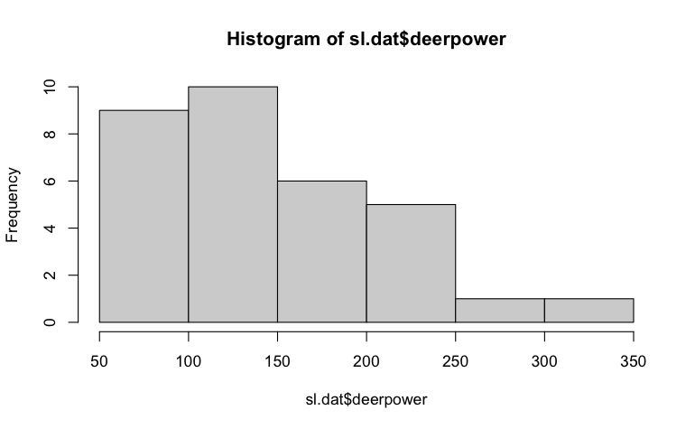

A histogram should show up on the screen!

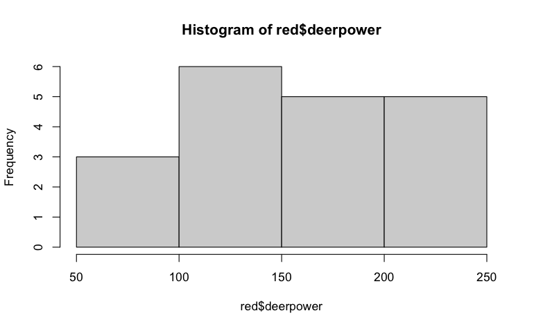